# Tvyal Newsletter

Aghasi Tavadyan

2023-10-30

*English summary below.*

Հարգելի գործընկեր,

Հուսով եմ լավ եք: Ներկայացնում եմ անցած շաբաթվա վերլուծությունները և աշխատանքները.

1. Դոլարայնացման և մոնետիզացիայի մակարդակը Հայաստանում
2. ԶԼՄ հաղորդակցություններ
3. English summary

## 1. Դոլարայնացման և մոնետիզացիայի մակարդակը Հայաստանում

```
Ես ձեզ պիտի խոստովանեմ, ինձ ավելի հեշտ է գծապատկերներ գծել,
տվյալները հետազոտել, համեմատաբար բարդ մեքենայական ուսուցման
մոդելներ կառոցել և կոդ գրել քան տեքստ գրել։
Տեքստ գրելը բարդ է։
Այս պահին ես գտնվում եմ տրանզիտով օտարերկրյա օդանավակայանում և սպասում եմ հաջորդ թռիչքիս։
Այսօրվա տեքստը քիչ է լինելու, բայց հուսով եմ ձեզ համար օգտակար կլինեն գծապատկերները։

-Աղասի
```

Ընդհանուր առմամբ դոլարացման մակարդակը տարբեր եղանականերով փորձում է գնահատել թե տնտեսությունում գտնվող փողի որ տոկոսն է կազմում արտարժույթ։ Ինչքան այս ցուցանիշը բարձր է այնքան ավելի ցածր է հավատը դեպի տնտեսություն և բանկային համակարգ։

Առաջին դիագրամը ցույց է տալիս Հայաստանում դոլարիզացիայի մակարդակը։ Գծապատկերում ավելի խոսուն է D2-ը ցուցանիշը, որը ռեզիդենտների արտարժութային ավանդների և վարկերի հարաբերակցությունն է ռեզիդենտների ընդհանուր ավանդներին և վարկերին։ Որքան փոքր է այս ցուցանիշը, այնքան մեծ է հավատը Հայաստանի բանկային համակարգի նկատմամբ։ Ըստ այդ ցուցանիշի՝ 2023 թվականի սեպտեմբերին դոլարի մակարդակը կազմում է 41 տոկոս։ Այս ցուցանիշը սկսել է նվազել 2016 թվականից՝ 2010 թվականից մինչ այդ այդ ցուցանիշը 60 տոկոսից բարձր էր։

**Գծապատկեր 1.** Դոլարայնացման մակարդակը Հայաստանում ըստ փողի զանգվածի

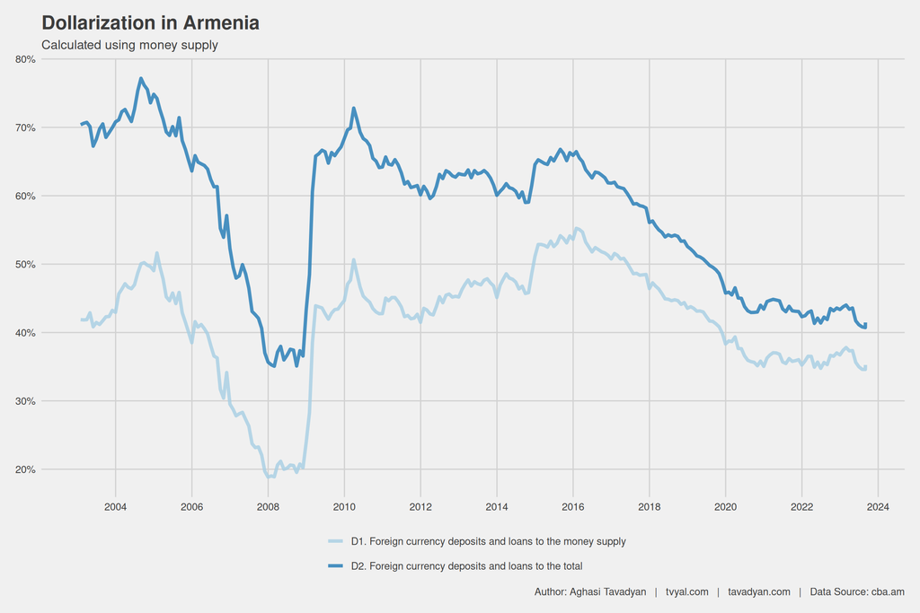

**Գծապատկեր 2.** Դոլարայնացման մակարդակը Հայաստանում ըստ արտարժույթով ցպահանջ ավանդների և վարկերի

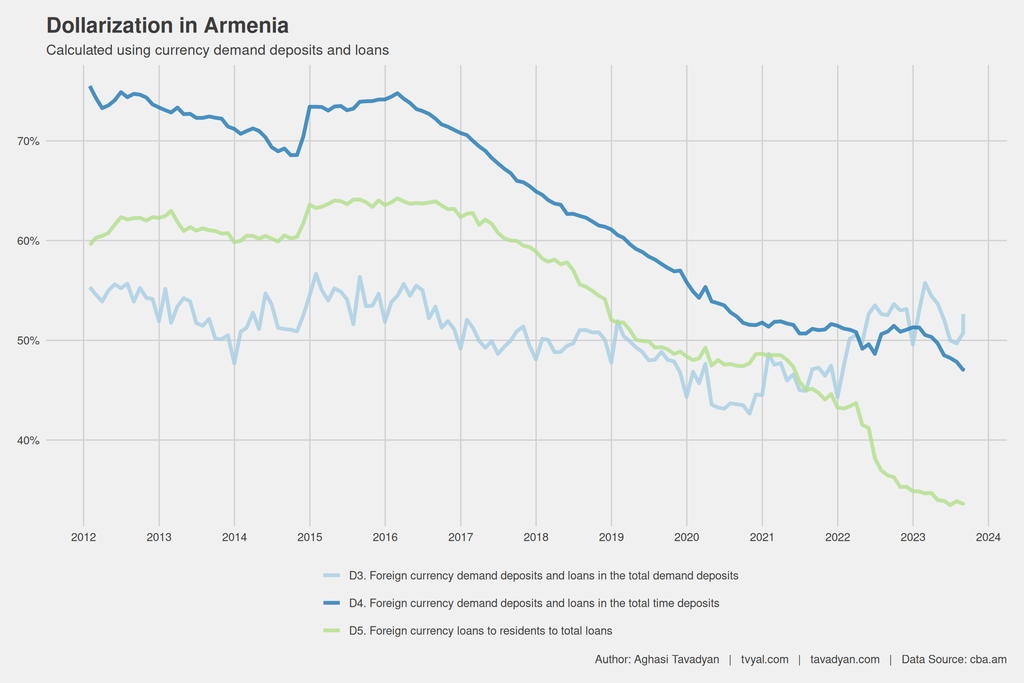

Երրորդ գծապատկերը ցույց է տալիս ՀՀ դրամով և արտաժույթով ավանդների հարաբերությունը ՀՆԱ-ին։ ՀՀ դրամով ավանդների մեջ են մտնում ցպահանջ և Ժամկետային ավանդները։ Տվյալները հարաբերած են ՀՆԱ-ի 12-ամսյա գումարային ցուցանիշին, որպեսզի փոփոխության դինամիկան ավելի հստակ երևա։ 2019 թվականի երկրոր կեսից դրամային ավանդների կշիռը սկսեց գրազանցել դոլարային ավանդների կշռին։ 2018 թվականից դոլարային ավանդների կշիռը սկսեց ընկնել։ 2023 թվականի սեպտեմբերի դրությամբ ընդհանուր դրամական ավանդները կազմում են մոտ 2.4 տրլն դրամ կամ ՀՆԱ-ի 26 տոկոսը, իսկ դոլարային ավանդները մոտ 1.7 տրիլիոն դրամ, կամ ՀՆԱ-ի մոտ 18 տոկոսը։

**Գծապատկեր 3.** ՀՀ դրամով և արտաժույթով ավանդների հարաբերությունը ՀՆԱ-ին

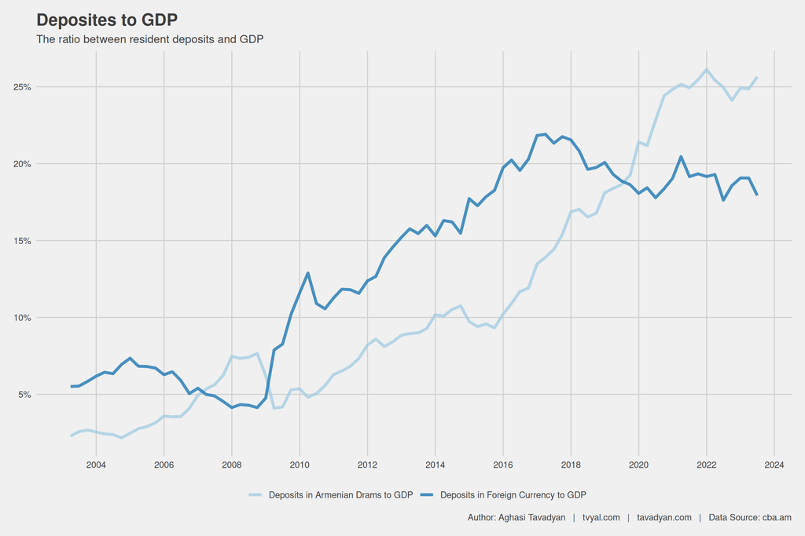

Գծապատկեր 4-ում ներկայացված է դրամայնացման կամ մոնետիզացիայի մակարդակը Հայաստանում, որը փողի զանգվածի և ՀՆԱ-ի հարաբերակցությունն է։ Տնտեսության դրամայնացումը ազգային տնտեսության չափիչ է, որն արտացոլում է նրա հագեցվածությունը իրացվելի ակտիվներով: Դրամայնացման մակարդակը որոշվում է ինչպես ազգային ֆինանսական համակարգի, այնպես էլ ողջ տնտեսության զարգացմամբ։ Տնտեսության դրամայնացումը պայմանավորում է նաև կապիտալի շարժի ազատությունը։ Այստեղ հիմնական ցուցանիշը M2 դրամայնացումն է, որը ներկայումս կազմում է 33 տոկոս։ Ընդհանուր ՀՆԱ-ն հակված է փոփոխության գծային ձևով, մինչդեռ փողի զանգվածը կարող է փոխվել էքսպոնենցիալ: Դրա շնորհիվ դրամայնացման մակարդակը վկայում է տնտեսական զարգացման մասին։ Բոլոր զարգացած տնտեսություններում այս ցուցանիշը կազմում է ավելի քան 60 տոկոս։

**Գծապատկեր 4.** Մոնետիզացիայի մակարդակը Հայաստանում

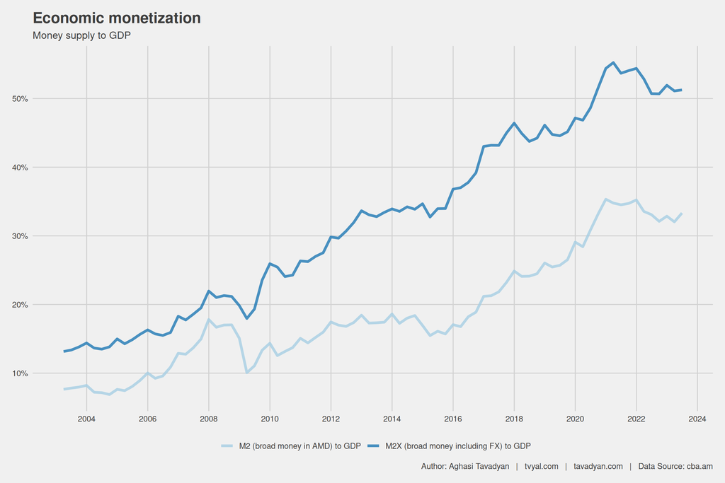

## 2. ԶԼՄ հաղորդակցություններ

Այս շաբաթ տվել եմ հարցազրույց hetq.am-ին Հայաստանից ավտոմեքենաների բումի և տրենդի մարման մասին։

հատված նյութից՝

```
«Ինչպես ավտոմեքենաների, այնպես էլ մյուս ապրանքների վերաարատահանումը
Հայաստանի տնտեսության վրա կարճաժամկետ դրական ազդեցություն է թողնում։
Դրանք, եթե ավելի պարզ ասենք, վերավաճառքներ են, որոնց ընթացքում արտահանողները
եկամուտ ու շահույթ են ստանում։ Հիմա Ռուսաստանը «սոված» շուկա է և արագորեն
կլանում է Հայաստանից վերաարատահանվող ապրանքները։ Բայց եթե մի օր արգելքները
հանվեն Ռուսաստանի վրայից, հայկական կողմի վերաարատահանողները միանգամից կտուժեն,
կտուժի նաև ամբողջ հայկական տնտեսությունը։ Սակայն, եթե միայն ավտոմեքենաները
դիտարկենք, գուցե ազդեցությունը այդքան մեծ չլինի»:
```

[Ավելին՝ կարդացեք նյութը](https://hetq.am/hy/article/161508)

[figure not shown]

## 3. English Summary

**Dollarization and economy monetization in Armenia.**

I am in international transit, amid airports, no summary in English this time, although the charts speak for themselves.

Այս վերլուծությունը առկա է նաև [մեր կայքեջում](https://www.tvyal.com/newsletter/2023_10_30), այս վերլուծության կոդը դրված է նաև [Github-ում](https://github.com/tavad/tvyal_newsletter)։

Եթե հնարավոր է, խնդրում եմ այս նյութը ուղարկել նաև այն մարդկանց, ում այն կարծում եք կարող է հետաքրքրել:

Սպասեք հաջորդ հաղորդագրությանը մի շաբաթվա ընթացքում:

Հարգանքներով,  
Աղասի Թավադյան  
30.10.2023  
[tvyal.com](https://www.tvyal.com/)  
[tavadyan.com](https://www.tavadyan.com/)

**Ուշադրություն. Ձեր էլ.փոստը մեյլիսթի մեջ է, որի միջոցով ես կիսվում եմ շաբաթական նյութեր, որոնք հիմնականում ներկայացնում են Հայաստանի տնտեսությանը: Նյութերը ներառում են գծապատկերներ, [տվյալների բազաներ](https://github.com/tavad/tvyal_newsletter), տեսանյութեր, հոդվածներ, [առցանց վահանակներ](https://www.tvyal.com/projects), տնտեսական գործիքներ, կանխատեսումներ և հաշվետվություններ: Եթե ցանկանում եք չեղարկել բաժանորդագրությունը, խնդրում եմ տեղեկացրեք ինձ, և ես կհեռացնեմ ձեր էլ. փոստը ցուցակից: Գրեք նաև եթե ունեք մենկնաբանություններ:**

**Important! Your email is part of the mailing list where I share weekly materials primarily focused on the Armenian economy. These materials encompass charts, [databases](https://github.com/tavad/tvyal_newsletter), videos, articles, [online dashboards](https://www.tvyal.com/projects), economic tools, forecasts, and reports. If you wish to unsubscribe, please let me know, and I will remove your email from the list. Please share your comments as well․**